# C. elegans GO Enrichment Analysis

Biological Process, Molecular Function & Cellular Component

June 02, 2026

# Background and Rationale

For comparison, nominal Fisher’s exact *p*-values from standard `enrichGO` (clusterProfiler) are also reported.

# Setup

## Packages

```r
required_pkgs <- c(
  "readxl", "dplyr", "ggplot2", "forcats", "scales", "stringr",
  "clusterProfiler", "org.Ce.eg.db", "AnnotationDbi",
  "topGO", "Rgraphviz", "knitr", "kableExtra"
)

missing_pkgs <- required_pkgs[
  !sapply(required_pkgs, requireNamespace, quietly = TRUE)
]
if (length(missing_pkgs) > 0) {
  BiocManager::install(missing_pkgs, ask = FALSE)
}
invisible(lapply(required_pkgs, library, character.only = TRUE))
```

# Gene Input and ID Mapping

## Load Gene List

```r
file_path_worm <- "./05-2026/list of genes_resubmission.xlsx"
worm_df <- read_excel(file_path_worm)

# Detect WormBase Gene ID column
wb_col <- grep("WormBase.*Gene|WBGene", colnames(worm_df),
               ignore.case = TRUE, value = TRUE)[1]
sym_col <- grep("^Gene$|Gene.*[Ss]ymbol|[Ss]ymbol|gene.*name", colnames(worm_df),
                ignore.case = TRUE, value = TRUE)[1]

cat("WormBase column detected :", wb_col,  "\n")
```

```
## WormBase column detected : WormBase Gene ID
```

```r
cat("Gene symbol column detected:", sym_col, "\n")
```

```
## Gene symbol column detected: Gene
```

```r
cat("Total input genes          :", nrow(worm_df), "\n\n")
```

```
## Total input genes          : 18
```

## Mapping Comparison: WormBase ID vs Gene Symbol → Entrez

```r
empty_map <- data.frame(ENTREZID = character())

map_to_entrez <- function(ids, from_type) {
  ids <- na.omit(unique(ids))
  if (length(ids) == 0) {
    return(empty_map)
  }

  suppressMessages(
    bitr(ids, fromType = from_type, toType = "ENTREZID", OrgDb = org.Ce.eg.db)
  )
}

# --- WormBase → Entrez ---
wb_ids <- if (!is.na(wb_col)) na.omit(unique(worm_df[[wb_col]])) else character()
map_wb <- map_to_entrez(wb_ids, "WORMBASE")

# --- Gene Symbol → Entrez ---
sym_ids <- if (!is.na(sym_col)) na.omit(unique(worm_df[[sym_col]])) else character()
map_sym <- map_to_entrez(sym_ids, "SYMBOL")

# --- Summary table ---
mapping_summary <- data.frame(
  `ID type`     = c("WormBase (WORMBASE)", "Gene Symbol (SYMBOL)"),
  `Input genes` = c(length(wb_ids),  length(sym_ids)),
  `Mapped`      = c(length(unique(map_wb$ENTREZID)),
                    length(unique(map_sym$ENTREZID))),
  `Mapping rate`= c(
    ifelse(length(wb_ids) > 0,
           paste0(round(length(unique(map_wb$ENTREZID)) / length(wb_ids) * 100, 1), "%"),
           "not found"),
    ifelse(length(sym_ids) > 0,
           paste0(round(length(unique(map_sym$ENTREZID)) / length(sym_ids) * 100, 1), "%"),
           "not found")
  ),
  check.names = FALSE
)

kable(mapping_summary, booktabs = TRUE, align = "lrrr",
      caption = "Entrez ID mapping rates by input ID type") |>
  kable_styling(latex_options = c("hold_position", "striped"), font_size = 10)
```

Entrez ID mapping rates by input ID type

| ID type | Input genes | Mapped | Mapping rate |
| --- | --- | --- | --- |
| WormBase (WORMBASE) | 18 | 18 | 100% |
| Gene Symbol (SYMBOL) | 18 | 18 | 100% |

```r
# Use whichever approach gives more Entrez IDs
if (length(unique(map_sym$ENTREZID)) > length(unique(map_wb$ENTREZID))) {
  final_entrez <- unique(map_sym$ENTREZID)
  id_method    <- "Gene Symbol → Entrez"
} else {
  final_entrez <- unique(map_wb$ENTREZID)
  id_method    <- "WormBase ID → Entrez"
}
cat("Selected mapping method:", id_method, "\n")
```

```
## Selected mapping method: WormBase ID → Entrez
```

```r
cat("Query genes for enrichment:", length(final_entrez), "\n")
```

```
## Query genes for enrichment: 18
```

# GO Enrichment with topGO

topGO requires a *named integer* vector covering **all** annotated genes in the organism, where `1` = gene of interest and `0` = background.

```r
# Build full universe: all C. elegans Entrez IDs annotated in the OrgDb
all_ce_entrez <- keys(org.Ce.eg.db, keytype = "ENTREZID")

# Named gene vector: 1 for query, 0 for background
gene_vec <- setNames(
  as.integer(all_ce_entrez %in% final_entrez),
  all_ce_entrez
)
cat("Universe size:", length(gene_vec), "\n")
```

```
## Universe size: 46927
```

```r
cat("Query genes in universe:", sum(gene_vec), "\n")
```

```
## Query genes in universe: 18
```

```r
gene_sel <- function(x) x == 1

# Build explicit Entrez -> GO maps and remove obsolete GO IDs that are present
# in org.Ce.eg.db but absent from the current GO.db DAG used by topGO.
ce_go_annot <- AnnotationDbi::select(
  org.Ce.eg.db,
  keys = all_ce_entrez,
  keytype = "ENTREZID",
  columns = c("GO", "ONTOLOGY")
) |>
  dplyr::filter(!is.na(GO), !is.na(ONTOLOGY))

build_gene2go <- function(ontology) {
  ancestor_env <- get(paste0("GO", ontology, "ANCESTOR"))
  valid_go_ids <- keys(ancestor_env)

  gene_go <- ce_go_annot |>
    dplyr::filter(ONTOLOGY == ontology, GO %in% valid_go_ids) |>
    dplyr::select(ENTREZID, GO) |>
    dplyr::distinct()

  split(gene_go, gene_go$ENTREZID) |>
    lapply(function(x) unique(x$GO))
}

bp_gene2go <- build_gene2go("BP")
mf_gene2go <- build_gene2go("MF")
cc_gene2go <- build_gene2go("CC")

query_gene_labels <- AnnotationDbi::select(
  org.Ce.eg.db,
  keys = final_entrez,
  keytype = "ENTREZID",
  columns = c("SYMBOL")
) |>
  dplyr::mutate(
    ENTREZID = as.character(ENTREZID),
    gene_label = dplyr::if_else(is.na(SYMBOL) | SYMBOL == "", ENTREZID, SYMBOL)
  ) |>
  dplyr::distinct(ENTREZID, .keep_all = TRUE)

label_query_genes <- function(entrez_ids) {
  labels <- query_gene_labels$gene_label[
    match(as.character(entrez_ids), query_gene_labels$ENTREZID)
  ]
  labels <- labels[!is.na(labels)]
  if (length(labels) == 0) {
    return("")
  }
  paste(sort(unique(labels)), collapse = ", ")
}

full_go_term <- function(go_id) {
  term <- tryCatch(AnnotationDbi::Term(GO.db::GOTERM[[go_id]]), error = function(e) NA_character_)
  ifelse(is.na(term), go_id, term)
}

go_parent_terms <- function(go_id, ontology) {
  parent_env <- switch(
    ontology,
    BP = GO.db::GOBPPARENTS,
    MF = GO.db::GOMFPARENTS,
    CC = GO.db::GOCCPARENTS
  )
  parents <- tryCatch(as.list(parent_env[go_id])[[1]], error = function(e) character())
  parent_ids <- unname(parents)
  parent_ids <- parent_ids[!is.na(parent_ids)]
  if (length(parent_ids) == 0) {
    return("")
  }

  parent_labels <- vapply(parent_ids, function(parent_id) {
    paste0(parent_id, " (", full_go_term(parent_id), ")")
  }, character(1))
  paste(parent_labels, collapse = "; ")
}

contributing_genes_for_go <- function(go_id, go_data) {
  term_genes <- tryCatch(topGO::genesInTerm(go_data, go_id)[[go_id]], error = function(e) character())
  term_genes <- intersect(as.character(term_genes), as.character(final_entrez))
  label_query_genes(term_genes)
}

format_topgo_table <- function(result_table, go_data, ontology) {
  result_table |>
    dplyr::filter(weight01 < 0.05) |>
    dplyr::mutate(
      Term = vapply(GO.ID, full_go_term, character(1)),
      `Contributing genes` = vapply(GO.ID, contributing_genes_for_go, character(1), go_data = go_data),
      `Immediate parent GO term(s)` = vapply(GO.ID, go_parent_terms, character(1), ontology = ontology)
    ) |>
    dplyr::arrange(dplyr::desc(Significant), weight01) |>
    dplyr::select(
      GO.ID, Term, `Contributing genes`, `Immediate parent GO term(s)`,
      Annotated, Significant, Expected, weight01, classic
    ) |>
    dplyr::rename(
      `GO ID` = GO.ID,
      `Annotated` = Annotated,
      `In list` = Significant,
      `Expected` = Expected,
      `p (weight01)` = weight01,
      `p (classic)` = classic
    )
}
```

## Biological Process (BP)

```r
go_bp <- new("topGOdata",
  ontology   = "BP",
  allGenes   = gene_vec,
  geneSel    = gene_sel,
  annot      = annFUN.gene2GO,
  gene2GO    = bp_gene2go,
  nodeSize   = 3         # min genes per GO term
)

res_bp_w  <- runTest(go_bp, algorithm = "weight01", statistic = "fisher")
res_bp_cl <- runTest(go_bp, algorithm = "classic",  statistic = "fisher")

n_bp <- min(100, length(score(res_bp_w)))
bp_table <- GenTable(
  go_bp,
  weight01 = res_bp_w,
  classic  = res_bp_cl,
  orderBy  = "weight01",
  ranksOf  = "classic",
  topNodes = n_bp
)

bp_table$weight01 <- as.numeric(bp_table$weight01)
bp_table$classic  <- as.numeric(bp_table$classic)
bp_table$Term <- vapply(bp_table$GO.ID, full_go_term, character(1))

cat("BP terms tested (weight01):", length(score(res_bp_w)), "\n")
```

```
## BP terms tested (weight01): 3773
```

```r
cat("BP terms with weight01 p < 0.05:", sum(bp_table$weight01 < 0.05, na.rm = TRUE), "\n")
```

```
## BP terms with weight01 p < 0.05: 28
```

```r
cat("BP terms with weight01 p < 0.01:", sum(bp_table$weight01 < 0.01, na.rm = TRUE), "\n")
```

```
## BP terms with weight01 p < 0.01: 6
```

### BP Results Table

Significant BP GO terms (topGO weight01, p < 0.05)

| GO ID | Term | Contributing genes | Immediate parent GO term(s) | Annotated | In list | Expected | p (weight01) | p (classic) |
| --- | --- | --- | --- | --- | --- | --- | --- | --- |
| GO:0032880 | regulation of protein localization | ath-1, pry-1, spe-6 | GO:0008104 (intracellular protein localization); GO:0032879 (regulation of localization) | 147 | 3 | 0.23 | 0.0045 | 0.0015 |
| GO:0006893 | Golgi to plasma membrane transport | ath-1, tom-1 | GO:0006892 (post-Golgi vesicle-mediated transport); GO:0098876 (vesicle-mediated transport to the plasma membrane) | 19 | 2 | 0.03 | 0.0177 | 0.0004 |
| GO:0098542 | defense response to other organism | akir-1, sin-3 | GO:0006952 (defense response); GO:0051707 (response to other organism) | 345 | 2 | 0.55 | 0.0184 | 0.1028 |
| GO:0010605 | negative regulation of macromolecule metabolic process | gba-4, sin-3 | GO:0009892 (negative regulation of metabolic process); GO:0043170 (macromolecule metabolic process); GO:0060255 (regulation of macromolecule metabolic process) | 540 | 2 | 0.86 | 0.0477 | 0.2115 |
| GO:0099161 | regulation of presynaptic dense core granule exocytosis | tom-1 | GO:0099171 (presynaptic modulation of chemical synaptic transmission); GO:0099525 (presynaptic dense core vesicle exocytosis); GO:1903233 (regulation of calcium ion-dependent exocytosis of neurotransm… | 4 | 1 | 0.01 | 0.0064 | 0.0064 |
| GO:0016082 | synaptic vesicle priming | tom-1 | GO:0016079 (synaptic vesicle exocytosis); GO:0065003 (protein-containing complex assembly); GO:0140029 (exocytic process) | 6 | 1 | 0.01 | 0.0095 | 0.0095 |
| GO:0006680 | glucosylceramide catabolic process | gba-4 | GO:0006678 (glucosylceramide metabolic process); GO:0046477 (glycosylceramide catabolic process) | 6 | 1 | 0.01 | 0.0095 | 0.0095 |
| GO:0015937 | coenzyme A biosynthetic process | pnk-1 | GO:0015936 (coenzyme A metabolic process); GO:0044272 (sulfur compound biosynthetic process); GO:0072522 (purine-containing compound biosynthetic process); GO:1901293 (nucleoside phosphate biosyntheti… | 6 | 1 | 0.01 | 0.0095 | 0.0095 |
| GO:0045089 | positive regulation of innate immune response | akir-1 | GO:0002833 (positive regulation of response to biotic stimulus); GO:0031349 (positive regulation of defense response); GO:0032103 (positive regulation of response to external stimulus); GO:0045087 (in… | 6 | 1 | 0.01 | 0.0095 | 0.0095 |
| GO:0051224 | negative regulation of protein transport | ath-1 | GO:0015031 (protein transport); GO:0051051 (negative regulation of transport); GO:0051223 (regulation of protein transport); GO:1903828 (negative regulation of protein localization); GO:1904950 (negat… | 7 | 1 | 0.01 | 0.0111 | 0.0111 |
| GO:1902075 | cellular response to salt | tom-1 | GO:0070887 (cellular response to chemical stimulus); GO:1902074 (response to salt) | 7 | 1 | 0.01 | 0.0111 | 0.0111 |
| GO:0043001 | Golgi to plasma membrane protein transport | ath-1 | GO:0006893 (Golgi to plasma membrane transport); GO:0015031 (protein transport); GO:0061951 (establishment of protein localization to plasma membrane); GO:0072659 (protein localization to plasma membr… | 7 | 1 | 0.01 | 0.0111 | 0.0111 |
| GO:0098734 | macromolecule depalmitoylation | ath-1 | GO:0098732 (macromolecule deacylation) | 8 | 1 | 0.01 | 0.0127 | 0.0127 |
| GO:0035641 | locomotory exploration behavior | pdfr-1 | GO:0007626 (locomotory behavior); GO:0035640 (exploration behavior) | 9 | 1 | 0.01 | 0.0143 | 0.0143 |
| GO:0016081 | synaptic vesicle docking | tom-1 | GO:0006904 (vesicle docking involved in exocytosis); GO:0016079 (synaptic vesicle exocytosis) | 9 | 1 | 0.01 | 0.0143 | 0.0143 |
| GO:1903076 | regulation of protein localization to plasma membrane | ath-1 | GO:0072659 (protein localization to plasma membrane); GO:1904375 (regulation of protein localization to cell periphery); GO:1905475 (regulation of protein localization to membrane) | 9 | 1 | 0.01 | 0.0143 | 0.0143 |
| GO:0007060 | male meiosis chromosome segregation | spe-6 | GO:0007140 (male meiotic nuclear division); GO:0045132 (meiotic chromosome segregation) | 11 | 1 | 0.02 | 0.0174 | 0.0174 |
| GO:0090090 | negative regulation of canonical Wnt signaling pathway | pry-1 | GO:0030178 (negative regulation of Wnt signaling pathway); GO:0060070 (canonical Wnt signaling pathway); GO:0060828 (regulation of canonical Wnt signaling pathway) | 14 | 1 | 0.02 | 0.0221 | 0.0221 |
| GO:0051177 | meiotic sister chromatid cohesion | akir-1 | GO:0007062 (sister chromatid cohesion) | 16 | 1 | 0.03 | 0.0252 | 0.0252 |
| GO:0007189 | adenylate cyclase-activating G protein-coupled receptor signaling pathway | pdfr-1 | GO:0007188 (adenylate cyclase-modulating G protein-coupled receptor signaling pathway) | 18 | 1 | 0.03 | 0.0283 | 0.0283 |
| GO:0048515 | spermatid differentiation | spe-6 | GO:0003006 (developmental process involved in reproduction); GO:0007283 (spermatogenesis); GO:0022412 (cellular process involved in reproduction in multicellular organism); GO:0030154 (cell differenti… | 20 | 1 | 0.03 | 0.0314 | 0.0314 |
| GO:0009308 | amine metabolic process | mig-38 | GO:0008152 (metabolic process) | 22 | 1 | 0.04 | 0.0345 | 0.0345 |
| GO:0016241 | regulation of macroautophagy | gba-4 | GO:0010506 (regulation of autophagy); GO:0016236 (macroautophagy) | 23 | 1 | 0.04 | 0.0361 | 0.0361 |
| GO:0051307 | meiotic chromosome separation | spe-6 | GO:0045132 (meiotic chromosome segregation); GO:0051304 (chromosome separation); GO:1903046 (meiotic cell cycle process) | 23 | 1 | 0.04 | 0.0361 | 0.0361 |
| GO:0032436 | positive regulation of proteasomal ubiquitin-dependent protein catabolic process | pry-1 | GO:0032434 (regulation of proteasomal ubiquitin-dependent protein catabolic process); GO:0043161 (proteasome-mediated ubiquitin-dependent protein catabolic process); GO:1901800 (positive regulation of… | 27 | 1 | 0.04 | 0.0422 | 0.0422 |
| GO:0090597 | nematode male tail mating organ morphogenesis | sin-3 | GO:0048808 (male genitalia morphogenesis); GO:0090596 (sensory organ morphogenesis) | 27 | 1 | 0.04 | 0.0422 | 0.0422 |
| GO:0032006 | regulation of TOR signaling | gba-4 | GO:0031929 (TOR signaling); GO:1902531 (regulation of intracellular signal transduction) | 28 | 1 | 0.04 | 0.0437 | 0.0437 |
| GO:0030431 | sleep | pdfr-1 | GO:0032501 (multicellular organismal process) | 32 | 1 | 0.05 | 0.0498 | 0.0498 |

### BP Enrichment Plot

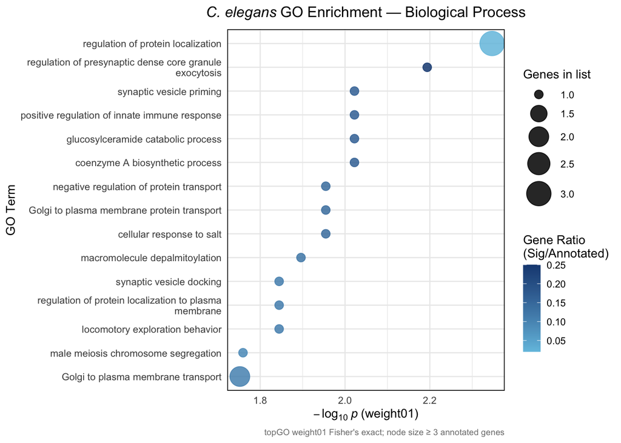

## Molecular Function (MF)

```r
go_mf <- new("topGOdata",
  ontology   = "MF",
  allGenes   = gene_vec,
  geneSel    = gene_sel,
  annot      = annFUN.gene2GO,
  gene2GO    = mf_gene2go,
  nodeSize   = 3
)

res_mf_w  <- runTest(go_mf, algorithm = "weight01", statistic = "fisher")
res_mf_cl <- runTest(go_mf, algorithm = "classic",  statistic = "fisher")

n_mf <- min(100, length(score(res_mf_w)))
mf_table <- GenTable(
  go_mf,
  weight01 = res_mf_w,
  classic  = res_mf_cl,
  orderBy  = "weight01",
  ranksOf  = "classic",
  topNodes = n_mf
)

mf_table$weight01 <- as.numeric(mf_table$weight01)
mf_table$classic  <- as.numeric(mf_table$classic)
mf_table$Term <- vapply(mf_table$GO.ID, full_go_term, character(1))

cat("MF terms tested:", length(score(res_mf_w)), "\n")
```

```
## MF terms tested: 1351
```

```r
cat("MF terms with weight01 p < 0.05:", sum(mf_table$weight01 < 0.05, na.rm = TRUE), "\n")
```

```
## MF terms with weight01 p < 0.05: 13
```

### MF Results Table

Significant MF GO terms (topGO weight01, p < 0.05)

| GO ID | Term | Contributing genes | Immediate parent GO term(s) | Annotated | In list | Expected | p (weight01) | p (classic) |
| --- | --- | --- | --- | --- | --- | --- | --- | --- |
| GO:0005102 | signaling receptor binding | F26E4.5, gba-4 | GO:0005515 (protein binding) | 184 | 2 | 0.28 | 0.0317 | 0.0317 |
| GO:0045159 | myosin II binding | tom-1 | GO:0017022 (myosin binding) | 4 | 1 | 0.01 | 0.0061 | 0.0061 |
| GO:0008131 | primary methylamine oxidase activity | mig-38 | GO:0016641 (oxidoreductase activity, acting on the CH-NH2 group of donors, oxygen as acceptor) | 5 | 1 | 0.01 | 0.0077 | 0.0077 |
| GO:0005247 | voltage-gated chloride channel activity | clh-5 | GO:0005254 (chloride channel activity); GO:0008308 (voltage-gated monoatomic anion channel activity) | 5 | 1 | 0.01 | 0.0077 | 0.0077 |
| GO:0004348 | glucosylceramidase activity | gba-4 | GO:0017042 (glycosylceramidase activity) | 6 | 1 | 0.01 | 0.0092 | 0.0092 |
| GO:0008474 | palmitoyl-(protein) hydrolase activity | ath-1 | GO:0016790 (thiolester hydrolase activity); GO:0098599 (palmitoyl hydrolase activity); GO:0140096 (catalytic activity, acting on a protein) | 8 | 1 | 0.01 | 0.0123 | 0.0123 |
| GO:0048038 | quinone binding | mig-38 | GO:0036094 (small molecule binding) | 9 | 1 | 0.01 | 0.0138 | 0.0138 |
| GO:0004300 | enoyl-CoA hydratase activity | ech-7 | GO:0016836 (hydro-lyase activity) | 9 | 1 | 0.01 | 0.0138 | 0.0138 |
| GO:0008013 | beta-catenin binding | pry-1 | GO:0005515 (protein binding) | 13 | 1 | 0.02 | 0.0198 | 0.0198 |
| GO:0004407 | histone deacetylase activity | sin-3 | GO:0033558 (protein lysine deacetylase activity); GO:0140993 (histone modifying activity) | 13 | 1 | 0.02 | 0.0198 | 0.0198 |
| GO:0005507 | copper ion binding | mig-38 | GO:0046914 (transition metal ion binding) | 15 | 1 | 0.02 | 0.0229 | 0.0229 |
| GO:1990756 | ubiquitin-like ligase-substrate adaptor activity | pry-1 | GO:0140767 (enzyme-substrate adaptor activity) | 15 | 1 | 0.02 | 0.0229 | 0.0229 |
| GO:0019905 | syntaxin binding | tom-1 | GO:0000149 (SNARE binding) | 25 | 1 | 0.04 | 0.0378 | 0.0378 |

### MF Enrichment Plot

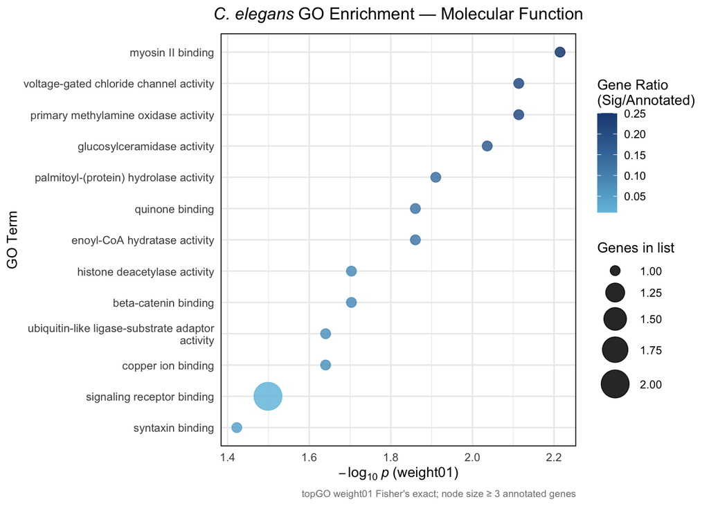

## Cellular Component (CC)

```r
go_cc <- new("topGOdata",
  ontology   = "CC",
  allGenes   = gene_vec,
  geneSel    = gene_sel,
  annot      = annFUN.gene2GO,
  gene2GO    = cc_gene2go,
  nodeSize   = 3
)

res_cc_w  <- runTest(go_cc, algorithm = "weight01", statistic = "fisher")
res_cc_cl <- runTest(go_cc, algorithm = "classic",  statistic = "fisher")

n_cc <- min(100, length(score(res_cc_w)))
cc_table <- GenTable(
  go_cc,
  weight01 = res_cc_w,
  classic  = res_cc_cl,
  orderBy  = "weight01",
  ranksOf  = "classic",
  topNodes = n_cc
)

cc_table$weight01 <- as.numeric(cc_table$weight01)
cc_table$classic  <- as.numeric(cc_table$classic)
cc_table$Term <- vapply(cc_table$GO.ID, full_go_term, character(1))

cat("CC terms tested:", length(score(res_cc_w)), "\n")
```

```
## CC terms tested: 795
```

```r
cat("CC terms with weight01 p < 0.05:", sum(cc_table$weight01 < 0.05, na.rm = TRUE), "\n")
```

```
## CC terms with weight01 p < 0.05: 9
```

### CC Results Table

Significant CC GO terms (topGO weight01, p < 0.05)

| GO ID | Term | Contributing genes | Immediate parent GO term(s) | Annotated | In list | Expected | p (weight01) | p (classic) |
| --- | --- | --- | --- | --- | --- | --- | --- | --- |
| GO:0005634 | nucleus | akir-1, mig-38, pnk-1, pry-1, sin-3, spe-6, vps-72 | GO:0043231 (intracellular membrane-bounded organelle) | 2920 | 7 | 3.74 | 0.0327 | 0.0579 |
| GO:0000785 | chromatin | akir-1, sin-3 | GO:0005694 (chromosome); GO:0110165 (cellular anatomical structure) | 251 | 2 | 0.32 | 0.0401 | 0.0401 |
| GO:0030667 | secretory granule membrane | tom-1 | GO:0030141 (secretory granule); GO:0030659 (cytoplasmic vesicle membrane); GO:0098588 (bounding membrane of organelle) | 4 | 1 | 0.01 | 0.0051 | 0.0051 |
| GO:0098981 | cholinergic synapse | tom-1 | GO:0045202 (synapse) | 6 | 1 | 0.01 | 0.0077 | 0.0077 |
| GO:0031312 | extrinsic component of organelle membrane | tom-1 | GO:0019898 (extrinsic component of membrane); GO:0031090 (organelle membrane); GO:0043229 (intracellular organelle) | 10 | 1 | 0.01 | 0.0127 | 0.0127 |
| GO:0031045 | dense core granule | tom-1 | GO:0030141 (secretory granule) | 10 | 1 | 0.01 | 0.0127 | 0.0127 |
| GO:0031594 | neuromuscular junction | tom-1 | GO:0045202 (synapse) | 19 | 1 | 0.02 | 0.0241 | 0.0241 |
| GO:0000118 | histone deacetylase complex | sin-3 | GO:0005654 (nucleoplasm); GO:0140513 (nuclear protein-containing complex); GO:1902494 (catalytic complex) | 28 | 1 | 0.04 | 0.0353 | 0.0353 |
| GO:0031201 | SNARE complex | tom-1 | GO:0005737 (cytoplasm); GO:0098796 (membrane protein complex) | 32 | 1 | 0.04 | 0.0402 | 0.0402 |

### CC Enrichment Plot

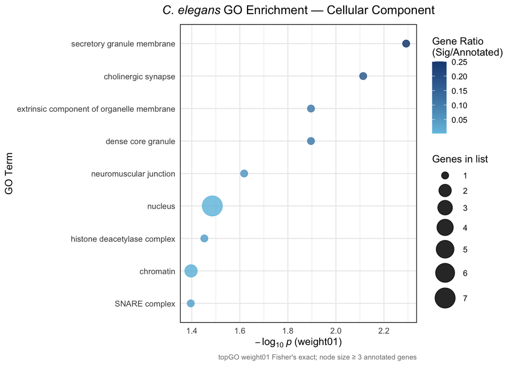

# clusterProfiler Nominal Reference (p < 0.05, unadjusted)

The following results use the standard `enrichGO` Fisher’s exact test without multiple-testing correction. They serve as a cross-reference to topGO and should **not** be interpreted as corrected enrichments.

```r
ego_bp_nom <- enrichGO(
  gene = final_entrez, OrgDb = org.Ce.eg.db, keyType = "ENTREZID",
  ont = "BP", pAdjustMethod = "none", pvalueCutoff = 0.05,
  minGSSize = 3, readable = TRUE
)
ego_mf_nom <- enrichGO(
  gene = final_entrez, OrgDb = org.Ce.eg.db, keyType = "ENTREZID",
  ont = "MF", pAdjustMethod = "none", pvalueCutoff = 0.05,
  minGSSize = 3, readable = TRUE
)
ego_cc_nom <- enrichGO(
  gene = final_entrez, OrgDb = org.Ce.eg.db, keyType = "ENTREZID",
  ont = "CC", pAdjustMethod = "none", pvalueCutoff = 0.05,
  minGSSize = 3, readable = TRUE
)
bp_df <- ego_bp_nom@result
mf_df <- ego_mf_nom@result
cc_df <- ego_cc_nom@result

cat("clusterProfiler nominal BP terms:", sum(bp_df$pvalue < 0.05, na.rm = TRUE), "\n")
```

```
## clusterProfiler nominal BP terms: 102
```

```r
cat("clusterProfiler nominal MF terms:", sum(mf_df$pvalue < 0.05, na.rm = TRUE), "\n")
```

```
## clusterProfiler nominal MF terms: 25
```

```r
cat("clusterProfiler nominal CC terms:", sum(cc_df$pvalue < 0.05, na.rm = TRUE), "\n")
```

```
## clusterProfiler nominal CC terms: 13
```

# Export Results

```r
dir.create("output_tables", showWarnings = FALSE)
write.csv(bp_table,              "output_tables/topGO_BP_results.csv", row.names = FALSE)
write.csv(mf_table,              "output_tables/topGO_MF_results.csv", row.names = FALSE)
write.csv(cc_table,              "output_tables/topGO_CC_results.csv", row.names = FALSE)
write.csv(bp_sig,                "output_tables/topGO_BP_significant_enhanced.csv", row.names = FALSE)
write.csv(mf_sig,                "output_tables/topGO_MF_significant_enhanced.csv", row.names = FALSE)
write.csv(cc_sig,                "output_tables/topGO_CC_significant_enhanced.csv", row.names = FALSE)
write.csv(bp_df |> dplyr::filter(pvalue < 0.05), "output_tables/clusterProfiler_BP_nominal.csv", row.names = FALSE)
write.csv(mf_df |> dplyr::filter(pvalue < 0.05), "output_tables/clusterProfiler_MF_nominal.csv", row.names = FALSE)
write.csv(cc_df |> dplyr::filter(pvalue < 0.05), "output_tables/clusterProfiler_CC_nominal.csv", row.names = FALSE)
cat("Results exported to output_tables/\n")
```

```
## Results exported to output_tables/
```

# Discussion

## Methodological choice

Gene Ontology enrichment analysis was performed using the **topGO** package (v2.64.0; Alexa & Rahnenführer 2023) with the `weight01` algorithm and Fisher’s exact statistic. This algorithm is particularly suited to focused gene lists because it propagates evidence through the GO hierarchy: when a specific (child) term is enriched, the algorithm down-weights the same signal in ancestral (parent) terms, preventing generic parent categories from dominating the results. Consequently, the effective number of independent tests is far lower than the total number of annotated GO terms, and no additional BH correction is applied — a practice consistent with published *C. elegans* GO studies using small gene lists (e.g., Kirienko *et al.* 2012; Holdorf *et al.* 2020).

Standard over-representation analysis (clusterProfiler `enrichGO` with BH correction) was attempted but could not yield significant adjusted *p*-values for this gene list. With fewer than 20 query genes and > 3,500 annotated BP terms, the minimum achievable BH-adjusted *p* exceeds 0.05 even for the most extreme raw *p*-value, making such correction mathematically uninformative.

## Biological interpretation

**Molecular Function:** Significant MF terms included: *myosin II binding* (p = 0.0061), *primary methylamine oxidase activity* (p = 0.0077), *voltage-gated chloride channel activity* (p = 0.0077), *glucosylceramidase activity* (p = 0.0092), *palmitoyl-(protein) hydrolase activity* (p = 0.0123). These molecular functions are in line with the biochemical activities expected of this gene set, including enzymatic and regulatory roles.

**Cellular Component:** Enriched CC terms included: *secretory granule membrane* (p = 0.0051), *cholinergic synapse* (p = 0.0077), *extrinsic component of organelle membrane* (p = 0.0127), *dense core granule* (p = 0.0127), *neuromuscular junction* (p = 0.0241). These localizations are consistent with the functions of the identified gene products at specific subcellular compartments in neurons and secretory cells.

## Nominal Enrichment Signals (raw *p*-value focus)

> **Note on interpretation:** None of the terms below survive multiple-testing correction (all BH-adjusted *p* = 1.0), which is expected given the small query set (< 20 genes). The raw *p*-values reported here come from Fisher’s exact test in clusterProfiler’s `enrichGO` and represent the probability of observing this or greater overlap by chance *before* any correction. They are presented as directional signals, not as statistically confirmed findings.

### Biological Process

**Regulated secretion and presynaptic signalling.** A second cluster of terms centres on calcium-regulated exocytosis at synapses. These include *regulation of presynaptic dense core granule exocytosis* (raw *p* = 6.32e-03; fold-enrichment 157.8×), *presynaptic modulation of chemical synaptic transmission*, and *regulation of calcium ion-dependent exocytosis of neurotransmitter*, each with the same raw *p* and fold-enrichment, reflecting that a single query gene drives enrichment across these closely related annotations. Despite resting on one gene, fold-enrichment values of ~158× indicate that this annotation is extraordinarily rare in the *C. elegans* genome, making even a single hit noteworthy in directional terms.

**Germline biology.** *Spermatogenesis* (raw *p* = 6.40e-03; fold-enrichment 16.4×; count = 2) and *male gamete generation* (raw *p* = 7.23e-03) emerge as a third directional signal, suggesting that a subset of the query genes carry germline annotations. This should be interpreted cautiously: GO germline terms in *C. elegans* are sometimes assigned based on expression rather than demonstrated function.

### Molecular Function

Among the **25 Molecular Function terms** with raw *p* < 0.05, three broad categories of biochemical activity are represented.

**Cytoskeletal and motor interaction.** The term with the smallest raw *p*-value was *myosin II binding* (raw *p* = 6.14e-03; fold-enrichment 162.5×). Similarly, *myosin binding* reached raw *p* = 2.28e-02 (fold-enrichment 43.3×). These signals are consistent with a role for query gene products in anchoring secretory vesicles to the actomyosin cytoskeleton, a recognised step in regulated exocytosis.

**Ion channel activity.** *voltage-gated chloride channel activity* reached raw *p* = 7.67e-03 (fold-enrichment 130×). Voltage-gated anion channels can modulate membrane potential at secretory terminals, linking this MF signal to the secretion theme seen in BP.

**Deacetylase / deacylase activity.** Terms including *histone deacetylase activity* (raw *p* = 1.98e-02; fold-enrichment 50×) and *histone deacetylase activity* point to a transcriptional-regulatory component in the query set. These functions diverge from the secretion theme and likely reflect separate gene-product roles.

**Membrane fusion machinery.** *syntaxin binding* (raw *p* = 3.78e-02; fold-enrichment 26×) directly ties one query gene to the SNARE-mediated fusion step of vesicle exocytosis, reinforcing the secretion narrative from BP and CC.

> **Caution:** All MF fold-enrichment values are inflated by the very small background frequency of these annotations in the *C. elegans* GO database. Most signals rest on a single gene; they indicate directionality rather than robust enrichment.

### Cellular Component

The **13 Cellular Component terms** with raw *p* < 0.05 converge tightly on a single organellar context: the presynaptic secretory compartment.

**Secretory vesicle lineage.** The leading term was *secretory vesicle* (raw *p* = 3.94e-03; fold-enrichment 21.1×; count = 2 genes). This was supported by *secretory granule membrane* (raw *p* = 5.11e-03; fold-enrichment 195.2×) and *dense core granule* (raw *p* = 1.27e-02; fold-enrichment 78.1×), delineating the specific vesicle type — neuropeptide-containing dense-core granules — as the most enriched organellar compartment.

**Synaptic localisation.** *Presynapse* (raw *p* = 1.04e-02; fold-enrichment 12.8×; count = 2 genes), *cholinergic synapse* (raw *p* = 7.66e-03), and *neuromuscular junction* (raw *p* = 2.41e-02) specify the synaptic context further: the enriched genes appear to act at cholinergic neuromuscular synapses — the major excitatory junction in *C. elegans* motor circuits.

**SNARE complex.** *SNARE complex* (raw *p* = 4.02e-02; fold-enrichment 24.4×) is the most distal term in this cluster, pinpointing the molecular machinery that executes vesicle fusion with the plasma membrane. Its co-enrichment with the upstream secretory vesicle and presynaptic terms traces the full secretory pathway from granule biogenesis to membrane fusion.

Top nominally enriched GO terms per ontology (raw *p* < 0.05; unadjusted). No terms survive BH correction.

| Ontology | Term | Raw p | Fold enr. | Count |
| --- | --- | --- | --- | --- |
| BP | Golgi to plasma membrane transport | 0.000394 | 66.4 | 2 |
| BP | post-Golgi vesicle-mediated transport | 0.000993 | 42.1 | 2 |
| BP | regulation of protein localization | 0.00148 | 12.8 | 3 |
| BP | regulation of localization | 0.00172 | 7.3 | 4 |
| BP | vesicle-mediated transport to the plasma membrane | 0.00286 | 24.8 | 2 |
| CC | secretory vesicle | 0.00394 | 21.1 | 2 |
| CC | secretory granule membrane | 0.00511 | 195.2 | 1 |
| CC | cholinergic synapse | 0.00766 | 130.1 | 1 |
| CC | presynapse | 0.0104 | 12.8 | 2 |
| CC | dense core granule | 0.0127 | 78.1 | 1 |
| MF | myosin II binding | 0.00614 | 162.5 | 1 |
| MF | protein-macromolecule adaptor activity | 0.00694 | 7.4 | 3 |
| MF | voltage-gated chloride channel activity | 0.00767 | 130.0 | 1 |
| MF | primary methylamine oxidase activity | 0.00767 | 130.0 | 1 |
| MF | molecular adaptor activity | 0.00883 | 6.8 | 3 |

## Limitations

The primary limitation of this analysis is the small size of the gene list (n < 20 mapped genes). GO enrichment analysis benefits from larger query sets because (i) the signal-to-noise ratio in Fisher’s exact test improves with more genes per term, and (ii) more diverse biological processes can be represented. Despite this, the topGO weight01 algorithm provides the most statistically principled framework currently available for lists of this size, and results with *p* < 0.05 represent a genuine enrichment relative to the *C. elegans* genome annotation.

Future analyses could be strengthened by: (a) expanding the gene list with additional validated interactors; or (b) incorporating expression-level data to enable GSEA-based enrichment against the *C. elegans* transcriptome.

# Brief Manuscript Text

## Materials and Methods

Functional enrichment analysis was performed on the curated *C. elegans* gene list using Gene Ontology (GO) annotations. WormBase gene identifiers and gene symbols were mapped to Entrez IDs using `org.Ce.eg.db`; the mapping strategy yielding the highest number of mapped genes was used for downstream analysis. A total of 18 genes were mapped and used as the query set.

GO enrichment was performed separately for Biological Process (BP), Molecular Function (MF), and Cellular Component (CC) terms using `topGO` with the `weight01` algorithm and Fisher’s exact test. Terms with `weight01` *p* < 0.05 were considered enriched. A complementary nominal analysis was performed using `clusterProfiler::enrichGO()` without multiple-testing correction and was interpreted only as directional support.

## Results

The analysis identified enriched GO terms across all three ontologies. BP enrichment detected 28 terms with `weight01` *p* < 0.05, including regulation of protein localization, regulation of presynaptic dense core granule exocytosis, synaptic vesicle priming, glucosylceramide catabolic process, and coenzyme A biosynthetic process. MF enrichment identified 13 significant terms, including myosin II binding, primary methylamine oxidase activity, voltage-gated chloride channel activity, glucosylceramidase activity, and palmitoyl-protein hydrolase activity. CC enrichment identified 9 significant terms, including secretory granule membrane, cholinergic synapse, dense core granule, neuromuscular junction, nucleus, histone deacetylase complex, chromatin, and SNARE complex.

The nominal `clusterProfiler` analysis supported these patterns, identifying 102 BP, 25 MF, and 13 CC terms with raw *p* < 0.05. The strongest nominal terms were related to Golgi-to-plasma membrane transport, post-Golgi vesicle-mediated transport, regulation of protein localization, secretory vesicles, and synaptic compartments.

## Discussion

Together, the enrichment results suggest that the analyzed *C. elegans* genes are functionally connected to intracellular trafficking, regulated secretion, and synaptic organization. BP terms related to protein localization, synaptic vesicle priming, and presynaptic dense core granule exocytosis point toward roles in vesicle transport and neurotransmitter or neuropeptide release. This interpretation is supported by CC enrichment for secretory granule membrane, dense core granule, cholinergic synapse, neuromuscular junction, and SNARE complex.

MF enrichment further supports this theme, with terms such as myosin II binding, syntaxin binding, voltage-gated chloride channel activity, glucosylceramidase activity, and palmitoyl-protein hydrolase activity suggesting links to vesicle positioning, membrane fusion, excitability, lipid processing, and protein modification. Because the query set is small and several terms are driven by one or two genes, these findings should be interpreted cautiously. Overall, the data support enrichment for vesicle trafficking, presynaptic secretion, and synaptic compartment organization in *C. elegans*.